# An Overview of the current Coronavirus States in US

AS2018421

10/1/2022

## packages need to install

```r
library(ggplot2)
library(maptools)
library(tibble)
library(tidyverse)
library(ggrepel)
library(png)
library(grid)
library(sp)
library(magrittr)
library(coronavirus)
```

# 1. Introduction

The United States of America (U.S.A. or USA), commonly known as the United States (U.S. or US) or America, is a transcontinental country located primarily in North America. It consists of 50 states, a federal district, five major unincorporated territories, nine minor outlying islands, and 326 Indian reservations. It is the third-largest country by total area.[d] The United States shares land borders with Canada to its north and with Mexico to its south. It has maritime borders with the Bahamas, Cuba, Russia, and other nations. With a population of over 331 million,it is the third most populous country in the world. The national capital is Washington, D.C., and the most populous city and financial center is New York City.

## 1.1 visualisation of the location on a world map

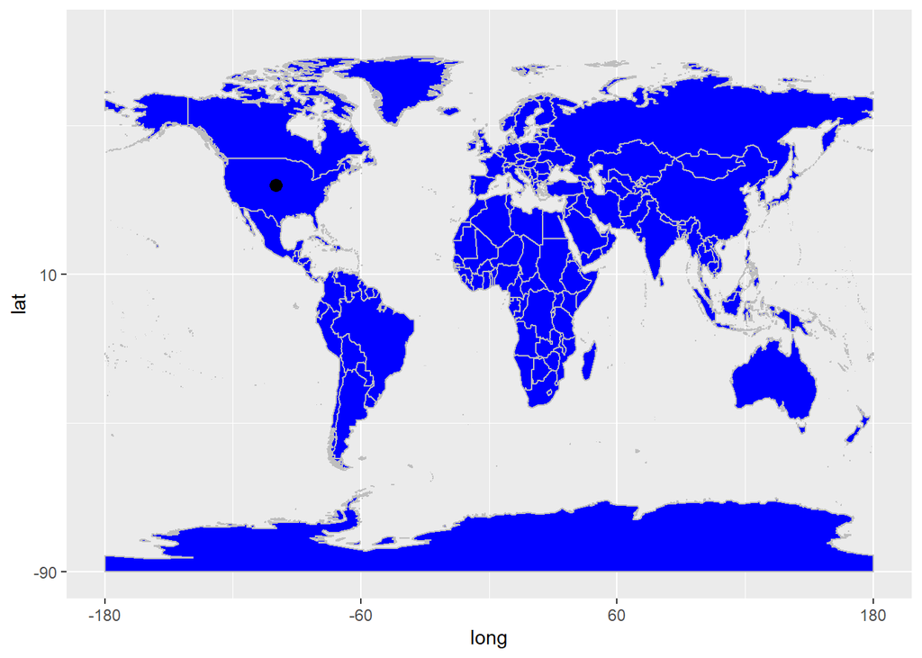

```r
us_corona <- coronavirus %>% filter(country == "US")
data(wrld_simpl)
p <- ggplot()+
  geom_polygon(data = wrld_simpl,
               aes(x = long, y = lat, group = group), fill = "blue", colour = "grey") +
  coord_cartesian(xlim = c(-180, 180), ylim = c(-90, 90)) +
  scale_x_continuous(breaks = seq(-180, 180, 120)) +
  scale_y_continuous(breaks = seq(-90, 90, 100))
p + geom_point(
  data = us_corona, aes(x = long, y = lat), color = "black" , size = 3
)
```

-Figure 1: location of US in a world map-

## 1.2 Covid - 19 pandemic in the United States(US)

# 2. Exploratory data analysis

## 2.1 Description of US corona dataset

```r
summary(us_corona)
```

```
##       date              province           country               lat
##  Min.   :2020-01-22   Length:2652        Length:2652        Min.   :40
##  1st Qu.:2020-08-29   Class :character   Class :character   1st Qu.:40
##  Median :2021-04-07   Mode  :character   Mode  :character   Median :40
##  Mean   :2021-04-07                                         Mean   :40
##  3rd Qu.:2021-11-14                                         3rd Qu.:40
##  Max.   :2022-06-23                                         Max.   :40
##       long          type               cases               uid
##  Min.   :-100   Length:2652        Min.   :-6298082   Min.   :840
##  1st Qu.:-100   Class :character   1st Qu.:       0   1st Qu.:840
##  Median :-100   Mode  :character   Median :    1561   Median :840
##  Mean   :-100                      Mean   :   33097   Mean   :840
##  3rd Qu.:-100                      3rd Qu.:   33155   3rd Qu.:840
##  Max.   :-100                      Max.   : 1383897   Max.   :840
##      iso2               iso3               code3     combined_key
##  Length:2652        Length:2652        Min.   :840   Length:2652
##  Class :character   Class :character   1st Qu.:840   Class :character
##  Mode  :character   Mode  :character   Median :840   Mode  :character
##                                        Mean   :840
##                                        3rd Qu.:840
##                                        Max.   :840
##    population        continent_name     continent_code
##  Min.   :329466283   Length:2652        Length:2652
##  1st Qu.:329466283   Class :character   Class :character
##  Median :329466283   Mode  :character   Mode  :character
##  Mean   :329466283
##  3rd Qu.:329466283
##  Max.   :329466283
```

```r
head(us_corona)
```

```
##         date province country lat long      type cases uid iso2 iso3 code3
## 1 2020-01-22     <NA>      US  40 -100 confirmed     1 840   US  USA   840
## 2 2020-01-23     <NA>      US  40 -100 confirmed     0 840   US  USA   840
## 3 2020-01-24     <NA>      US  40 -100 confirmed     1 840   US  USA   840
## 4 2020-01-25     <NA>      US  40 -100 confirmed     0 840   US  USA   840
## 5 2020-01-26     <NA>      US  40 -100 confirmed     3 840   US  USA   840
## 6 2020-01-27     <NA>      US  40 -100 confirmed     0 840   US  USA   840
##   combined_key population continent_name continent_code
## 1           US  329466283  North America             NA
## 2           US  329466283  North America             NA
## 3           US  329466283  North America             NA
## 4           US  329466283  North America             NA
## 5           US  329466283  North America             NA
## 6           US  329466283  North America             NA
```

```r
tail(us_corona)
```

```
##            date province country lat long     type cases uid iso2 iso3 code3
## 2647 2022-06-18     <NA>      US  40 -100 recovery     0 840   US  USA   840
## 2648 2022-06-19     <NA>      US  40 -100 recovery     0 840   US  USA   840
## 2649 2022-06-20     <NA>      US  40 -100 recovery     0 840   US  USA   840
## 2650 2022-06-21     <NA>      US  40 -100 recovery     0 840   US  USA   840
## 2651 2022-06-22     <NA>      US  40 -100 recovery     0 840   US  USA   840
## 2652 2022-06-23     <NA>      US  40 -100 recovery     0 840   US  USA   840
##      combined_key population continent_name continent_code
## 2647           US  329466283  North America             NA
## 2648           US  329466283  North America             NA
## 2649           US  329466283  North America             NA
## 2650           US  329466283  North America             NA
## 2651           US  329466283  North America             NA
## 2652           US  329466283  North America             NA
```

## 2.2 Analysis confirmed,deaths,recovered and active corona cases of US

### 2.2.1 Analysis confirmed corona cases of US

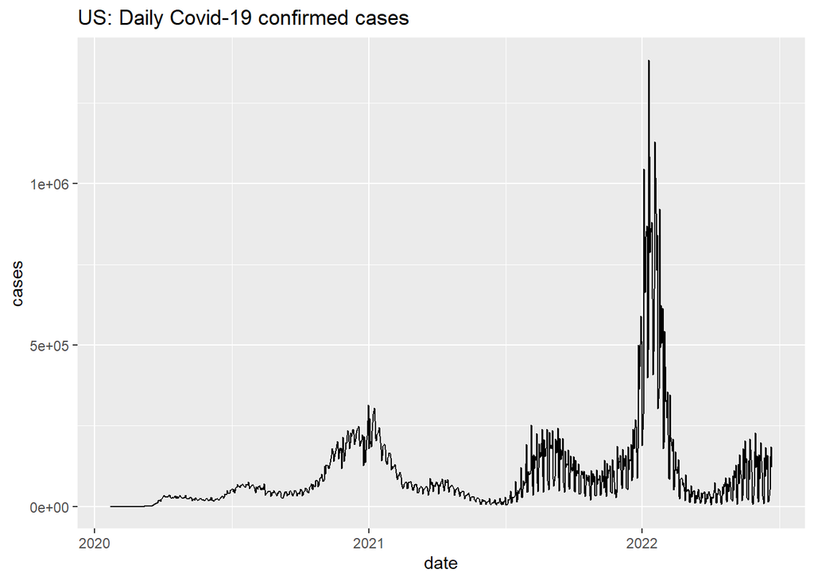

```r
confirmed_cases_us <- us_corona %>%  filter(type=="confirmed")
total_cases_us<-sum(confirmed_cases_us$cases)
ggplot(confirmed_cases_us, aes(x=date, y=cases)) + geom_line() + ggtitle("US: Daily Covid-19 confirmed cases")
```

```r
cat("Total cases in US=",total_cases_us)
```

```
## Total cases in US= 86757621
```

-Figure 2.1: Distribution of confirmed corona cases in US-

The total number of confirmed corona virus cases in US is 86757621 . The first case of COVID-19 was founded in Washington state in US.According to the graph we can see that most of corona cases has founded in around 2022. Starting 2021 most corona cases start to spread in US.

### 2.2.2 Analysis death corona cases in US

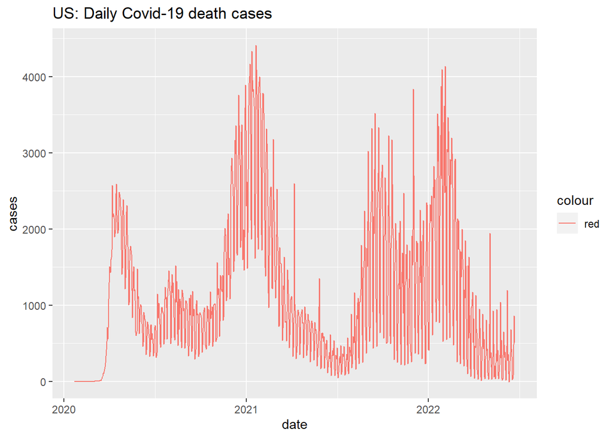

```r
death_cases_us <- us_corona %>% filter(type=="death")
total_deaths_us<-sum(death_cases_us$cases)
ggplot(death_cases_us, aes(x=date, y=cases,col="red")) + geom_line() + ggtitle("US: Daily Covid-19 death cases")
```

```r
cat("Total deaths in Us=",total_deaths_us)
```

```
## Total deaths in Us= 1015342
```

```r
death_rate_us<-(total_deaths_us/total_cases_us)*100
cat("Death rate in US=",death_rate_us)
```

```
## Death rate in US= 1.17032
```

-Figure 2.2: Distribution of corona death cases in US-

Total number of corona deaths in us is 1015342.From 2020 to 2022 shows huge number of deaths in US. The death rate in US is 1.17032.It is significantly higher than comparing other countries.

### 2.2.3 Analysis recovered corona cases in US

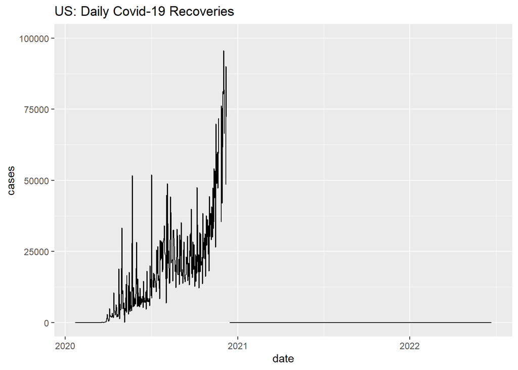

```r
recovered_cases_us <- us_corona %>% filter(type=="recovery")


total_recovers_us<-sum(recovered_cases_us$cases)
ggplot(recovered_cases_us, aes(x=date, y=cases)) + geom_line() + ggtitle("US: Daily Covid-19 Recoveries")+ylim(0,100000)
```

-Figure 2.3: Distribution of corona recovered cases in US-

From 2020 to 2021 corona recoveries of US are highly increasing. But from 2021 we cannot clearly see any recoveries according to the graph.

### 2.2.4 Analysis Active corona cases in US

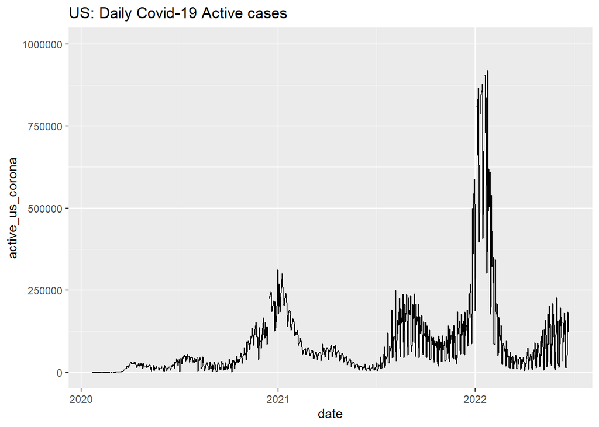

```r
us_corona2 <- us_corona %>% filter(cases >= 0)
coronaus_wider <- us_corona2 %>% pivot_wider(names_from=type, values_from=cases)
coronaus_wider$active_us_corona <- coronaus_wider$confirmed - coronaus_wider$death - coronaus_wider$recovery
ggplot(coronaus_wider, aes(x=date, y=active_us_corona)) + geom_line() + ggtitle("US: Daily Covid-19 Active cases")+ylim(0,1000000)
```

-Figure 2.4 : Distribution of Active corona cases in US-

Active corona cases = confirmed corona cases-deaths-corona recovery cases

According to Figure 2.4 graph shows that their are highly active corona cases reported in 2022 comparing 2020 and 2021.The number of reported active corona cases in 2022 is approximately 1000000.

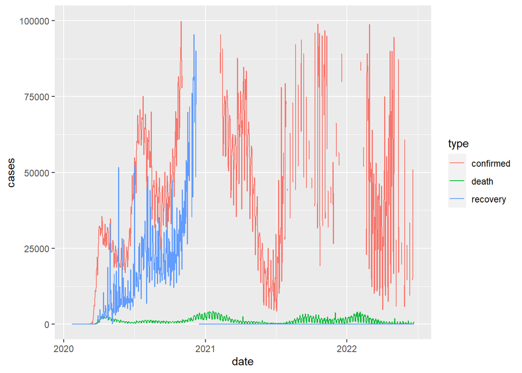

```r
ggplot(us_corona, aes(x=date, y=cases, col=type)) + geom_line()+ylim(0,100000)
```

-Figure 2.5 : Multiple time series plot of corona cases in US-

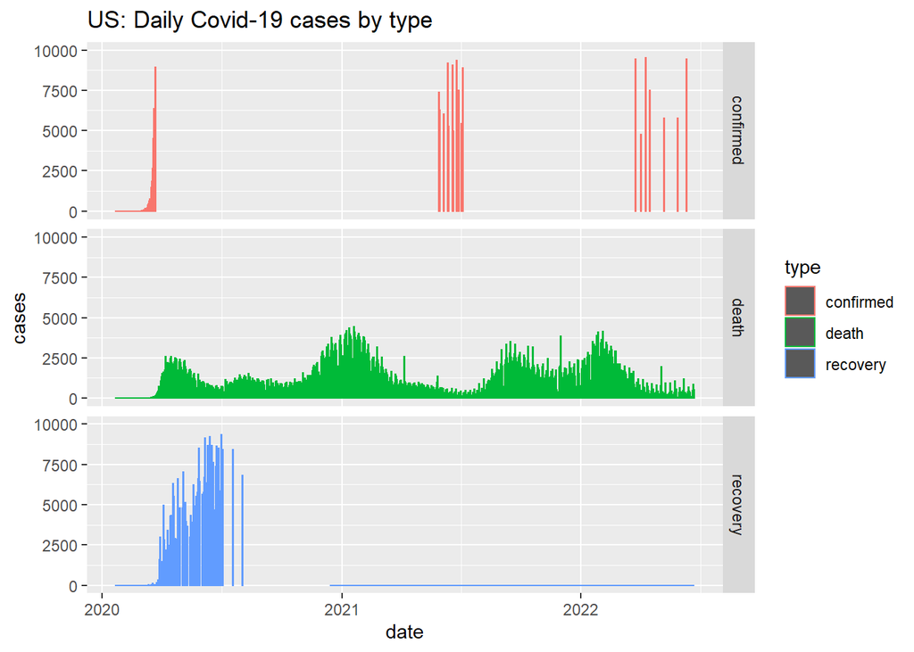

```r
us_corona2 <- us_corona %>% filter(cases >= 0)
ggplot(us_corona2, aes(x=date, y=cases, col=type)) + geom_col() + ggtitle("US: Daily Covid-19 cases by type") + facet_grid(type~.)+ylim(0,10000)
```

-Figure 2.6 Distribution of corona cases in US-

# 3. Comparison US corona cases with other countries

## 3.1 Comparison with neighbouring countries

The mainland of the United States(US) is bordered by the Atlantic Ocean in the west. The country boarders Canada in the north and Mexico in the south.Th United States share maritime boarders with the Bahamas,Cuba,and Russia. Then we compare covid-19 cases of US with these countries.

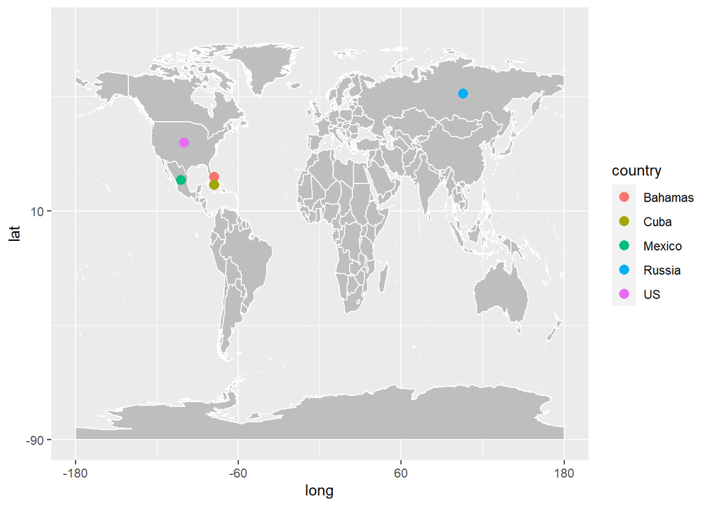

```r
compare_corona_1 <- coronavirus %>% filter(country == c("canada", "Mexico", "US","Bahamas","Cuba","Russia" ))

data("wrld_simpl")

p <- ggplot() +
  geom_polygon(
    data = wrld_simpl,
    aes(x = long, y = lat, group = group), fill = "grey", colour = "white"
  ) +
  coord_cartesian(xlim = c(-180, 180), ylim = c(-90, 90)) +
  scale_x_continuous(breaks = seq(-180, 180, 120)) +
  scale_y_continuous(breaks = seq(-90, 90, 100))

p +


    geom_point(
    data = compare_corona_1, aes(x = long, y = lat, col = country), size
    = 3
  )
```

-Figure 3.1: Location of US neighboring countries-

### 3.1.1 comparison us corona confirmed cases with neighboring countries

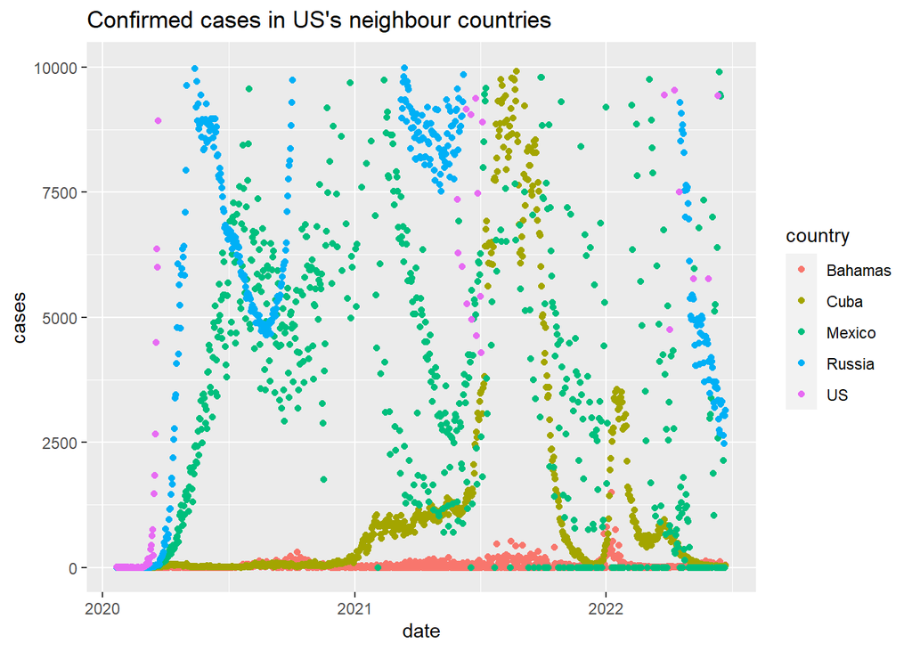

```r
bahamas_corona <- coronavirus  %>% filter(country == "Bahamas")
 confirmed_bahamas_corona <- bahamas_corona %>% filter(type=="confirmed")

 cuba_corona <- coronavirus  %>% filter(country == "Cuba")
confirmed_cuba_corona <- cuba_corona %>% filter(type=="confirmed")

mexico_corona <- coronavirus  %>% filter(country == "Mexico")
 confirmed_mexico_corona <- mexico_corona %>% filter(type=="confirmed")

 russia_corona <- coronavirus  %>% filter(country == "Russia")
 confirmed_russia_corona <- russia_corona %>% filter(type=="confirmed")

us_corona <- coronavirus  %>% filter(country == "US")
confirmed_us_corona <- us_corona %>% filter(type=="confirmed")

Neighbor_confirm <- rbind(confirmed_bahamas_corona, confirmed_cuba_corona, confirmed_mexico_corona, confirmed_russia_corona, confirmed_us_corona)


ggplot(Neighbor_confirm, aes(x=date, y=cases, col=country)) + geom_point() + ggtitle("Confirmed cases in US's neighbour countries") + ylim(0,10000)
```

-Figure 3.2: Distribution confirmed corona cases of US with neighboring countries-

Bahamas shows low number of confirmed corona cases with comparing US and other neighboring countries.From 2020 to 2021 Cuba has no any confirmed cases of corona but from 2021 to 2022 cuba confirmed more number of corona cases according to plot.Mexico and Russia both show high confirmed corona cases staring from 2020.

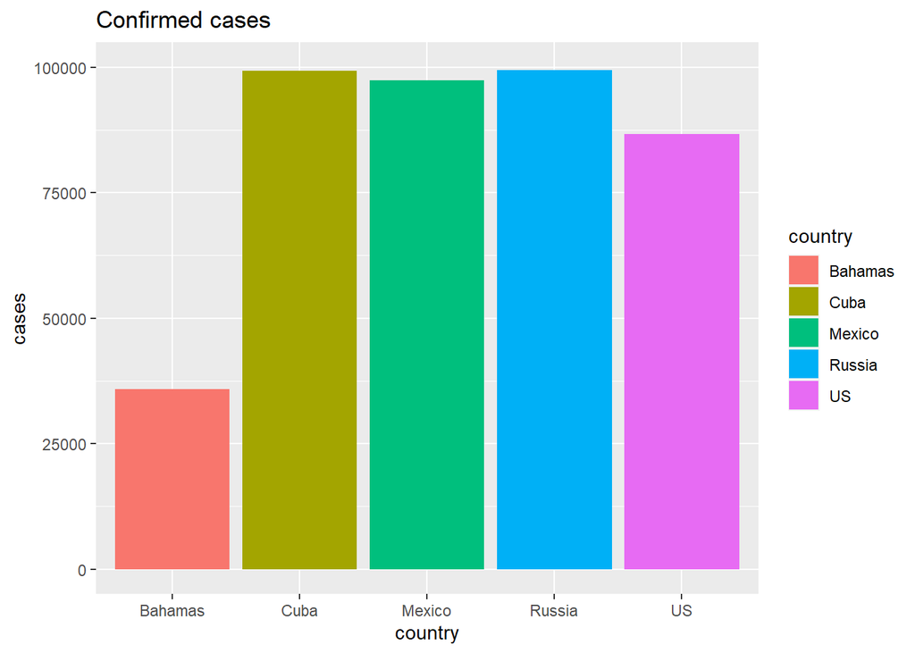

```r
ggplot(Neighbor_confirm, aes(x=country, y=cases,fill=country)) + geom_col() + ggtitle("Confirmed cases") + ylim(0,100000)
```

-Figure 3.3: Distribution confirmed corona cases of US neighboring countries-

According to Figure 3.3 Cuba,Mexico and Russia shows almost similar number of confirmed corona cases.Bahamas shows the lowest number of corona cases.Among Bahamas, Cuba, Mexico,Russia and US has the considerable cases.

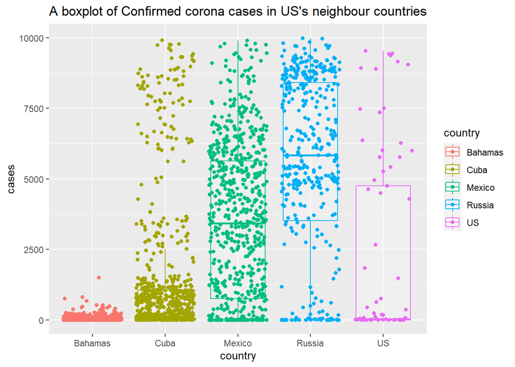

```r
ggplot(Neighbor_confirm, aes(x=country, y=cases, col= country)) + geom_boxplot(outlier.shape = NA, alpha = 0.2) + geom_jitter(aes(col=country)) + ggtitle("A boxplot of Confirmed corona cases in US's neighbour countries")+ylim(0,10000)
```

Figure 3.4: Box plot of confirmed corona cases in US’s with neighboring countries-